# Práctica 2: Limpieza y análisis de datos

## 3.1 Conversión de tipos de variables

### 3.1.1 Conversión de Size

```r
mask1 <- grepl("[M]$", googleplay_clean$Size)
mask2 <- grepl("[k]$", googleplay_clean$Size)

googleplay_clean$Size <- lapply(googleplay_clean$Size, function(x) gsub("[M]$", "", x))
googleplay_clean$Size <- lapply(googleplay_clean$Size, function(x) gsub("[k]$", "", x))
googleplay_clean$Size <- lapply(googleplay_clean$Size, function(x) gsub("Varies with device", "NaN", x))

googleplay_clean$Size <- as.numeric(googleplay_clean$Size)
googleplay_clean$Size <- (1000*mask2*googleplay_clean$Size) + (1000000*mask1*googleplay_clean$Size)

str(googleplay_clean$Size)
```

```
##  num [1:10840] 1.9e+07 1.4e+07 8.7e+06 2.5e+07 2.8e+06 5.6e+06 1.9e+07 2.9e+07 3.3e+07 3.1e+06 ...
```

### 3.1.2 Conversión de Price

Hemos observado que la variable *Price* está en formato chr, nuestro objetivo es convertirla a valor numérico. Para conseguirlo, debemos eliminar el símbolo del $ que acompaña a los precios:

```r
googleplay_clean$Price <- lapply(googleplay_clean$Price, function(x) gsub("\\$", "", x))
googleplay_clean$Price <- as.numeric(googleplay_clean$Price)

str(googleplay_clean$Price)
```

```
##  num [1:10840] 0 0 0 0 0 0 0 0 0 0 ...
```

### 3.1.3 Conversión de Reviews

Esta variable también está en formato chr, por lo que cambiaremos el formato a numérico:

```r
googleplay_clean$Reviews <- as.numeric(googleplay_clean$Reviews)
```

### 3.1.4 Conversión de Last.updated

```r
library(lubridate)
Time <- lapply(googleplay_clean$Last.Updated, function(x) parse_date_time(x,orders = "mdy"))

googleplay_clean$Last.Updated <- as.POSIXct(unlist(Time), origin = '1970-01-01')
googleplay_clean$Last.Updated <- as.character(ceiling_date(googleplay_clean$Last.Updated, "day"))
head(googleplay_clean)
```

```
##                                                  App       Category Rating
## 1     Photo Editor & Candy Camera & Grid & ScrapBook ART_AND_DESIGN    4.1
## 2                                Coloring book moana ART_AND_DESIGN    3.9
## 3 U Launcher Lite – FREE Live Cool Themes, Hide Apps ART_AND_DESIGN    4.7
## 4                              Sketch - Draw & Paint ART_AND_DESIGN    4.5
## 5              Pixel Draw - Number Art Coloring Book ART_AND_DESIGN    4.3
## 6                         Paper flowers instructions ART_AND_DESIGN    4.4
##   Reviews    Size    Installs Type Price Content.Rating
## 1     159 1.9e+07     10,000+ Free     0       Everyone
## 2     967 1.4e+07    500,000+ Free     0       Everyone
## 3   87510 8.7e+06  5,000,000+ Free     0       Everyone
## 4  215644 2.5e+07 50,000,000+ Free     0           Teen
## 5     967 2.8e+06    100,000+ Free     0       Everyone
## 6     167 5.6e+06     50,000+ Free     0       Everyone
##                      Genres Last.Updated        Current.Ver  Android.Ver
## 1              Art & Design   2018-01-08              1.0.0 4.0.3 and up
## 2 Art & Design;Pretend Play   2018-01-16              2.0.0 4.0.3 and up
## 3              Art & Design   2018-08-02              1.2.4 4.0.3 and up
## 4              Art & Design   2018-06-09 Varies with device   4.2 and up
## 5   Art & Design;Creativity   2018-06-21                1.1   4.4 and up
## 6              Art & Design   2017-03-27                1.0   2.3 and up
##   Multi_Genre
## 1          no
## 2         yes
## 3          no
## 4          no
## 5         yes
## 6          no
```

## 3.2 Análisis de valores perdidos

Ahora nos centraremos en el tratamiento de valores perdidos:

```r
colSums(is.na(googleplay_clean))
```

```
##            App       Category         Rating        Reviews           Size
##              0              0           1474              0           1695
##       Installs           Type          Price Content.Rating         Genres
##              0              0              0              0              0
##   Last.Updated    Current.Ver    Android.Ver    Multi_Genre
##              0              0              0              0
```

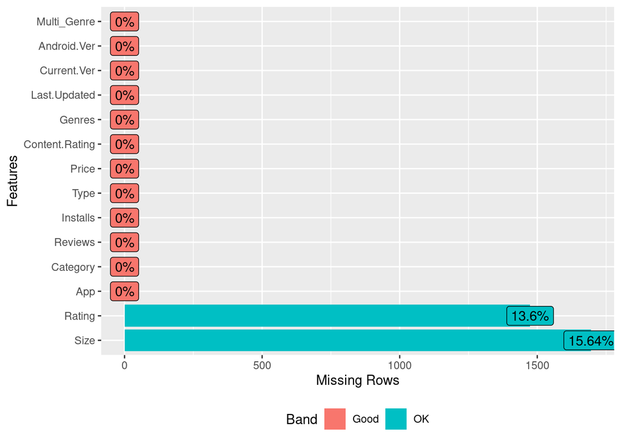

```r
plot_missing(googleplay_clean)
```

Las variables *Size* y *Rating* tienen valores perdidos. Puesto que la eliminicaión del las filas donde hay valores nulos supondría la pérdida de un 15,64% de los datos que disponemos, no podemos considerarlo como una opción. En su lugar, imputaremos los datos perdidos utilizando la librería *mice*, concretamente el *predictive mean matching*:

```r
library(mice)

tmpData <- mice(googleplay_clean, m=5, maxit = 50, method = 'pmm', seed = 500)
summary(tmpData)
```

```
## Class: mids
## Number of multiple imputations:  5
## Imputation methods:
##            App       Category         Rating        Reviews           Size
##             ""             ""          "pmm"             ""          "pmm"
##       Installs           Type          Price Content.Rating         Genres
##             ""             ""             ""             ""             ""
##   Last.Updated    Current.Ver    Android.Ver    Multi_Genre
##             ""             ""             ""             ""
## PredictorMatrix:
##          App Category Rating Reviews Size Installs Type Price Content.Rating
## App        0        0      1       1    1        0    0     1              0
## Category   0        0      1       1    1        0    0     1              0
## Rating     0        0      0       1    1        0    0     1              0
## Reviews    0        0      1       0    1        0    0     1              0
## Size       0        0      1       1    0        0    0     1              0
## Installs   0        0      1       1    1        0    0     1              0
##          Genres Last.Updated Current.Ver Android.Ver Multi_Genre
## App           0            0           0           0           0
## Category      0            0           0           0           0
## Rating        0            0           0           0           0
## Reviews       0            0           0           0           0
## Size          0            0           0           0           0
## Installs      0            0           0           0           0
## Number of logged events:  10
##   it im dep     meth            out
## 1  0  0     constant            App
## 2  0  0     constant       Category
## 3  0  0     constant       Installs
## 4  0  0     constant           Type
## 5  0  0     constant Content.Rating
## 6  0  0     constant         Genres
```

```r
data_clean <- complete(tmpData,1)
```

Verificamos que no hay ningún valor perdido:

```r
colSums(is.na(data_clean))
```

```
##            App       Category         Rating        Reviews           Size
##              0              0              0              0              0
##       Installs           Type          Price Content.Rating         Genres
##              0              0              0              0              0
##   Last.Updated    Current.Ver    Android.Ver    Multi_Genre
##              0              0              0              0
```

## 3.3 Discretización de variable categóricas

Antes de discretizar en catgorías las variables *chr*, primero analizamos el número de valores diferentes que tiene cada variable:

```r
# ¿Con qué variables tendría sentido un proceso de discretización?
apply(data_clean,2, function(x) length(unique(x)))
```

```
##            App       Category         Rating        Reviews           Size
##           9659             33             39           6001            459
##       Installs           Type          Price Content.Rating         Genres
##             20              2             92              6            119
##   Last.Updated    Current.Ver    Android.Ver    Multi_Genre
##           1377           2833             34              2
```

A partir de estos números, determinamos que será efectivo discretizar las variables *Category*, *Installs*, *Type*, *Content.rating*, *Android.Ver* y *Multi_Genre*:

```r
# Discretizamos las variables con pocas clases
cols<-c("Category","Installs","Type","Content.Rating", "Android.Ver", "Multi_Genre")
for (i in cols){
  data_clean[,i] <- as.factor(data_clean[,i])
}

# Después de los cambios, analizamos la nueva estructura del conjunto de datos
str(data_clean)
```

```
## 'data.frame':    10840 obs. of  14 variables:
##  $ App           : chr  "Photo Editor & Candy Camera & Grid & ScrapBook" "Coloring book moana" "U Launcher Lite – FREE Live Cool Themes, Hide Apps" "Sketch - Draw & Paint" ...
##  $ Category      : Factor w/ 33 levels "ART_AND_DESIGN",..: 1 1 1 1 1 1 1 1 1 1 ...
##  $ Rating        : num  4.1 3.9 4.7 4.5 4.3 4.4 3.8 4.1 4.4 4.7 ...
##  $ Reviews       : num  159 967 87510 215644 967 ...
##  $ Size          : num  1.9e+07 1.4e+07 8.7e+06 2.5e+07 2.8e+06 5.6e+06 1.9e+07 2.9e+07 3.3e+07 3.1e+06 ...
##  $ Installs      : Factor w/ 20 levels "0+","1,000,000,000+",..: 7 19 12 15 10 16 16 3 3 7 ...
##  $ Type          : Factor w/ 2 levels "Free","Paid": 1 1 1 1 1 1 1 1 1 1 ...
##  $ Price         : num  0 0 0 0 0 0 0 0 0 0 ...
##  $ Content.Rating: Factor w/ 6 levels "Adults only 18+",..: 2 2 2 5 2 2 2 2 2 2 ...
##  $ Genres        : chr  "Art & Design" "Art & Design;Pretend Play" "Art & Design" "Art & Design" ...
##  $ Last.Updated  : chr  "2018-01-08" "2018-01-16" "2018-08-02" "2018-06-09" ...
##  $ Current.Ver   : chr  "1.0.0" "2.0.0" "1.2.4" "Varies with device" ...
##  $ Android.Ver   : Factor w/ 34 levels "1.0 and up","1.5 and up",..: 16 16 16 19 21 9 16 19 11 16 ...
##  $ Multi_Genre   : Factor w/ 2 levels "no","yes": 1 2 1 1 2 1 1 1 1 2 ...
```

## 3.4 Análisis de outliers

```r
boxplot.stats(data_clean$Rating)$out
```

```
##   [1] 3.2 3.2 3.1 3.2 3.2 2.6 3.1 3.0 1.9 2.5 2.5 2.8 3.0 2.5 1.9 2.8 2.7 3.0
##  [19] 1.0 2.7 1.9 3.0 2.7 1.9 2.7 2.8 2.9 3.1 3.0 3.1 2.5 3.2 3.1 3.2 3.0 3.2
##  [37] 3.1 3.0 3.2 2.5 2.6 3.0 2.7 3.0 3.0 2.8 3.0 2.3 3.1 2.9 3.1 3.0 2.6 2.5
##  [55] 2.7 3.0 3.1 2.8 3.1 2.9 3.1 3.0 3.1 3.1 3.2 3.1 3.0 3.1 3.2 3.1 1.9 3.1
##  [73] 3.1 3.1 2.9 3.1 2.2 1.7 2.0 3.1 1.0 1.8 3.0 3.0 3.1 2.9 2.9 3.0 3.1 2.8
##  [91] 2.7 2.3 3.2 3.1 3.2 2.4 3.0 2.7 2.9 2.6 2.2 3.1 3.1 1.8 2.6 3.2 3.0 3.0
## [109] 3.1 3.2 3.0 3.1 3.0 2.4 2.9 2.4 3.2 2.5 3.2 1.9 2.5 3.2 2.7 2.9 2.2 2.8
## [127] 1.8 1.6 1.9 3.2 2.5 2.6 2.8 3.1 1.7 2.4 3.0 3.0 2.2 1.9 2.0 2.8 2.0 1.9
## [145] 2.3 2.9 3.0 1.0 3.0 2.6 3.0 3.1 3.2 3.0 2.6 2.8 2.8 2.8 3.0 2.9 2.9 2.9
## [163] 2.9 3.0 2.7 3.2 2.9 3.0 2.8 2.6 2.4 3.2 3.1 2.8 2.7 2.3 2.7 3.0 1.7 3.0
## [181] 3.1 2.9 2.7 3.0 3.1 3.0 3.0 3.0 3.2 3.2 2.1 2.1 2.4 3.1 1.9 2.5 2.6 3.0
## [199] 2.7 2.5 1.0 2.9 2.3 1.4 3.0 2.2 2.6 2.4 2.9 2.6 2.7 1.7 2.3 3.0 2.2 2.4
## [217] 2.9 3.0 2.6 2.4 2.3 1.0 2.8 2.2 3.2 3.0 3.2 3.0 3.2 1.0 3.2 3.0 3.1 3.2
## [235] 1.9 3.0 2.6 2.0 1.8 3.2 2.1 1.8 2.0 1.0 2.3 3.0 1.6 3.0 1.9 1.0 2.4 2.8
## [253] 3.1 2.5 2.8 2.7 2.8 1.8 2.9 2.2 3.1 3.0 3.1 2.9 2.8 3.0 2.0 1.7 3.0 2.9
```

[output cut: 16 more lines]

```r
boxplot.stats(data_clean$Reviews)$out
```

```
##    [1]   215644   194216   224399   295221   174531   271920   197136  2914724
##    [9]   577550   814080   246315   454060   155446   203130  1433233   363934
##   [17]   233757   341157   674730  1254730   217730  1002861   148945  1279184
##   [25]   159872   188841   207372   380837   286897   159872   159872   286897
##   [33]   217730  1002859  1013635   238970   564387 56642847 69119316  9642995
##   [41]  1429035  4604324  3419249 11334799   158679  3075028  4187998   659395
##   [49]  4785892  5149854   192948   437674  2473509   171031   615381  2451083
##   [57]  5387333  3648120   781810  3128250  2083237   541389   258556 17712922
##   [65] 69119316 56646578  4785988 11334973  3419433   594728  5387446 10484169
##   [73]  3128509  2451093   171031  2876500   781810   335646   350154   349384
##   [81]   346982   244863 10790289   330761 12842860  2546527   346980  9643041
##   [89]  3075118  2264916   541389  2473693  5150471  2511130  3648480 17714850
##   [97]  1133501   190613 11334973   177703   177263   237468   483565   552441
##  [105]   457283   205739  7820209  4604483  4188142   305218   183374   837842
##  [113]  3419513  4785988   594728 11335255 10484169  5387446   191032   350154
```

[output cut: 226 more lines]

```r
boxplot.stats(data_clean$Price)$out
```

```
##   [1]   4.99   4.99   4.99   4.99   3.99   3.99   6.99   1.49   2.99   3.99
##  [11]   7.99   3.99   3.99   5.99   3.99   3.99   4.99   2.99   3.49   4.99
##  [21]   2.99   3.99   2.99   2.99   2.99   1.99   4.99   4.99   4.99   5.99
##  [31]   6.99   9.99   4.99   3.99   2.99   3.99   2.99   3.99   3.99   4.99
##  [41]   3.99   2.99   7.49   2.99   0.99   0.99   0.99   4.99   2.99   4.99
##  [51]   2.99   4.99   4.99   2.99   2.99   3.99   3.99   2.99   2.99   3.99
##  [61]   3.99   6.99   2.99   9.00   0.99   5.49   9.99   6.99  10.00   3.99
##  [71]   5.99  24.99  11.99  79.99  11.99   2.99  16.99   3.99   2.99   9.99
##  [81]   3.99  14.99   2.99   3.99   2.99   1.00  29.99   2.99   2.99  12.99
##  [91]   4.99   2.99  14.99   5.99   3.49   0.99   2.49  24.99  10.99   1.99
## [101]  24.99   4.99   3.99   2.99   7.49   1.50   2.99   3.99   1.99   9.99
## [111]   3.99   3.99   3.99   7.99  14.99   9.99   3.99  19.99  29.99  15.99
## [121]   0.99  33.99   0.99  79.99   9.00  24.99   9.99  10.00  16.99  11.99
## [131]  29.99  14.99  74.99  11.99   6.99   5.49  14.99   9.99  33.99  29.99
## [141]  24.99  12.99  39.99   5.99   2.99  24.99  19.99   2.99   0.99   5.99
```

[output cut: 65 more lines]

```r
boxplot.stats(data_clean$Size)$out
```

```
##   [1] 8.5e+07 9.6e+07 9.4e+07 9.3e+07 9.3e+07 7.8e+07 7.8e+07 9.3e+07 9.9e+07
##  [10] 9.9e+07 9.8e+07 9.8e+07 7.9e+07 8.0e+07 9.6e+07 8.7e+07 9.8e+07 7.6e+07
##  [19] 8.8e+07 8.5e+07 8.8e+07 9.2e+07 9.2e+07 8.8e+07 8.1e+07 8.8e+07 8.5e+07
##  [28] 8.7e+07 1.0e+08 7.7e+07 7.7e+07 8.4e+07 9.3e+07 8.1e+07 9.7e+07 7.6e+07
##  [37] 7.6e+07 9.3e+07 9.5e+07 7.6e+07 9.3e+07 7.6e+07 9.5e+07 7.8e+07 7.7e+07
##  [46] 9.3e+07 8.8e+07 7.9e+07 1.0e+08 8.7e+07 7.9e+07 7.8e+07 9.6e+07 8.3e+07
##  [55] 7.6e+07 9.1e+07 9.7e+07 7.8e+07 7.9e+07 9.3e+07 7.8e+07 9.4e+07 7.8e+07
##  [64] 9.1e+07 9.3e+07 9.7e+07 7.9e+07 8.0e+07 9.7e+07 8.1e+07 7.7e+07 9.9e+07
##  [73] 9.5e+07 1.0e+08 8.0e+07 7.6e+07 7.6e+07 9.7e+07 7.5e+07 9.8e+07 7.8e+07
##  [82] 9.7e+07 8.7e+07 9.9e+07 8.5e+07 7.8e+07 7.5e+07 9.9e+07 9.9e+07 7.6e+07
##  [91] 9.8e+07 8.2e+07 9.6e+07 9.9e+07 9.9e+07 8.7e+07 8.7e+07 9.7e+07 8.6e+07
## [100] 7.5e+07 7.8e+07 9.7e+07 7.6e+07 1.0e+08 8.5e+07 8.7e+07 9.5e+07 7.8e+07
## [109] 9.8e+07 8.5e+07 1.0e+08 8.6e+07 8.0e+07 8.7e+07 7.9e+07 8.7e+07 9.1e+07
## [118] 9.5e+07 9.3e+07 8.2e+07 9.9e+07 8.7e+07 9.1e+07 8.5e+07 8.1e+07 8.2e+07
## [127] 9.8e+07 7.7e+07 9.9e+07 9.6e+07 9.6e+07 8.2e+07 8.4e+07 9.1e+07 9.2e+07
```

[output cut: 53 more lines]

# 4 Análisis

## 4.1 RandomForest

```r
library(randomForest)
library(caTools)
#use caTools function to split, SplitRatio for 70%:30% splitting
data1= sample.split(data_clean,SplitRatio = 0.3)

#subsetting into Train data
train =subset(data_clean,data1==TRUE)

#subsetting into Test data
test =subset(data_clean,data1==FALSE)

rf <- randomForest(Rating ~ Category + Reviews + Size + Installs + Type + Price + Content.Rating + Android.Ver + Multi_Genre, data = train)
pred <- predict(rf, newdata = test)
print(rf)
```

```
##
## Call:
##  randomForest(formula = Rating ~ Category + Reviews + Size + Installs +      Type + Price + Content.Rating + Android.Ver + Multi_Genre,      data = train)
##                Type of random forest: regression
##                      Number of trees: 500
## No. of variables tried at each split: 3
##
##           Mean of squared residuals: 0.2249448
##                     % Var explained: 11.76
```

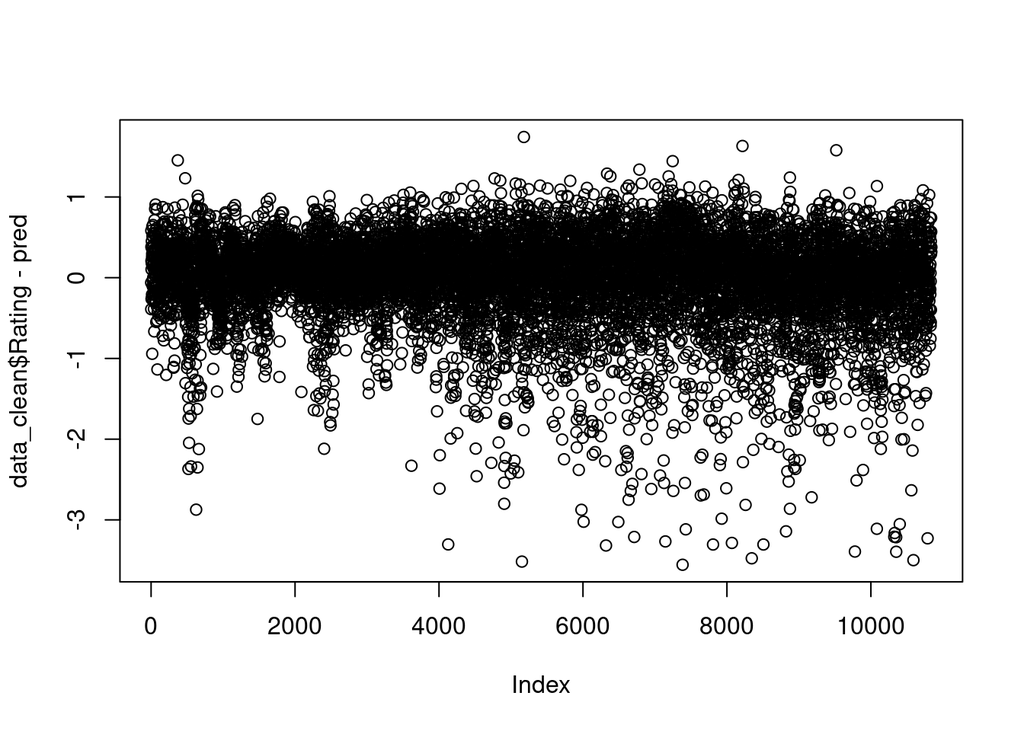

```r
plot(data_clean$Rating - pred)
```

```r
linear <- lm(Rating ~ Category + Reviews + Size + Installs + Type + Price + Content.Rating + Android.Ver + Multi_Genre, data = data_clean)
summary(linear)
```

```
##
## Call:
## lm(formula = Rating ~ Category + Reviews + Size + Installs +
##     Type + Price + Content.Rating + Android.Ver + Multi_Genre,
##     data = data_clean)
##
## Residuals:
##     Min      1Q  Median      3Q     Max
## -3.3876 -0.1720  0.0675  0.2874  1.1910
##
## Coefficients:
##                                 Estimate Std. Error t value Pr(>|t|)
## (Intercept)                    4.391e+00  4.740e-01   9.264  < 2e-16 ***
## CategoryAUTO_AND_VEHICLES     -1.548e-01  8.147e-02  -1.900 0.057409 .
## CategoryBEAUTY                -2.959e-02  9.133e-02  -0.324 0.745949
## CategoryBOOKS_AND_REFERENCE   -6.225e-02  6.959e-02  -0.894 0.371124
## CategoryBUSINESS              -2.193e-01  6.576e-02  -3.335 0.000857 ***
## CategoryCOMICS                -1.667e-01  8.906e-02  -1.872 0.061185 .
## CategoryCOMMUNICATION         -2.787e-01  6.664e-02  -4.182 2.92e-05 ***
## CategoryDATING                -3.580e-01  7.358e-02  -4.866 1.16e-06 ***
## CategoryEDUCATION             -2.482e-02  7.309e-02  -0.340 0.734196
## CategoryENTERTAINMENT         -3.236e-01  7.459e-02  -4.338 1.45e-05 ***
## CategoryEVENTS                 6.781e-02  8.716e-02   0.778 0.436564
## CategoryFAMILY                -1.855e-01  6.244e-02  -2.971 0.002975 **
## CategoryFINANCE               -1.905e-01  6.671e-02  -2.856 0.004294 **
## CategoryFOOD_AND_DRINK        -1.994e-01  7.552e-02  -2.641 0.008287 **
## CategoryGAME                  -1.617e-01  6.370e-02  -2.539 0.011139 *
## CategoryHEALTH_AND_FITNESS    -1.484e-01  6.707e-02  -2.212 0.026963 *
## CategoryHOUSE_AND_HOME        -1.793e-01  8.087e-02  -2.217 0.026630 *
## CategoryLIBRARIES_AND_DEMO    -6.762e-02  8.276e-02  -0.817 0.413890
## CategoryLIFESTYLE             -2.469e-01  6.639e-02  -3.719 0.000201 ***
## CategoryMAPS_AND_NAVIGATION   -3.168e-01  7.449e-02  -4.253 2.13e-05 ***
## CategoryMEDICAL               -1.572e-01  6.577e-02  -2.390 0.016874 *
## CategoryNEWS_AND_MAGAZINES    -2.167e-01  6.838e-02  -3.169 0.001534 **
## CategoryPARENTING             -6.809e-02  8.835e-02  -0.771 0.440929
## CategoryPERSONALIZATION       -9.787e-02  6.648e-02  -1.472 0.141006
## CategoryPHOTOGRAPHY           -2.356e-01  6.729e-02  -3.501 0.000465 ***
## CategoryPRODUCTIVITY          -1.851e-01  6.611e-02  -2.800 0.005122 **
## CategorySHOPPING              -1.724e-01  6.877e-02  -2.507 0.012175 *
## CategorySOCIAL                -1.559e-01  6.853e-02  -2.276 0.022893 *
```

[output cut: 58 more lines]

```
## Android.Ver5.1 and up          1.520e-01  3.631e-01   0.419 0.675556
## Android.Ver6.0 and up         -8.606e-02  3.545e-01  -0.243 0.808192
## Android.Ver7.0 - 7.1.1         3.483e-01  6.040e-01   0.577 0.564249
## Android.Ver7.0 and up         -7.844e-02  3.571e-01  -0.220 0.826129
## Android.Ver7.1 and up         -2.157e-01  4.504e-01  -0.479 0.631999
## Android.Ver8.0 and up         -1.325e-01  4.028e-01  -0.329 0.742221
## Android.VerNaN                 2.318e-01  4.935e-01   0.470 0.638585
## Android.VerVaries with device  2.233e-02  3.492e-01   0.064 0.949015
## Multi_Genreyes                 4.585e-02  2.550e-02   1.798 0.072207 .
## ---
## Signif. codes:  0 '***' 0.001 '**' 0.01 '*' 0.05 '.' 0.1 ' ' 1
##
## Residual standard error: 0.4923 on 10745 degrees of freedom
## Multiple R-squared:  0.08191,    Adjusted R-squared:  0.07388
## F-statistic:  10.2 on 94 and 10745 DF,  p-value: < 2.2e-16
```

# 5 Representacion de los resultados a partir de graficas y tablas

## 5.1 Instalar la libreria para la visualizacion

```r
library(ggplot2)
library(gridExtra)
library(GGally)
library(dplyr)
```

## 5.2 Distribucion de las puntuaciones

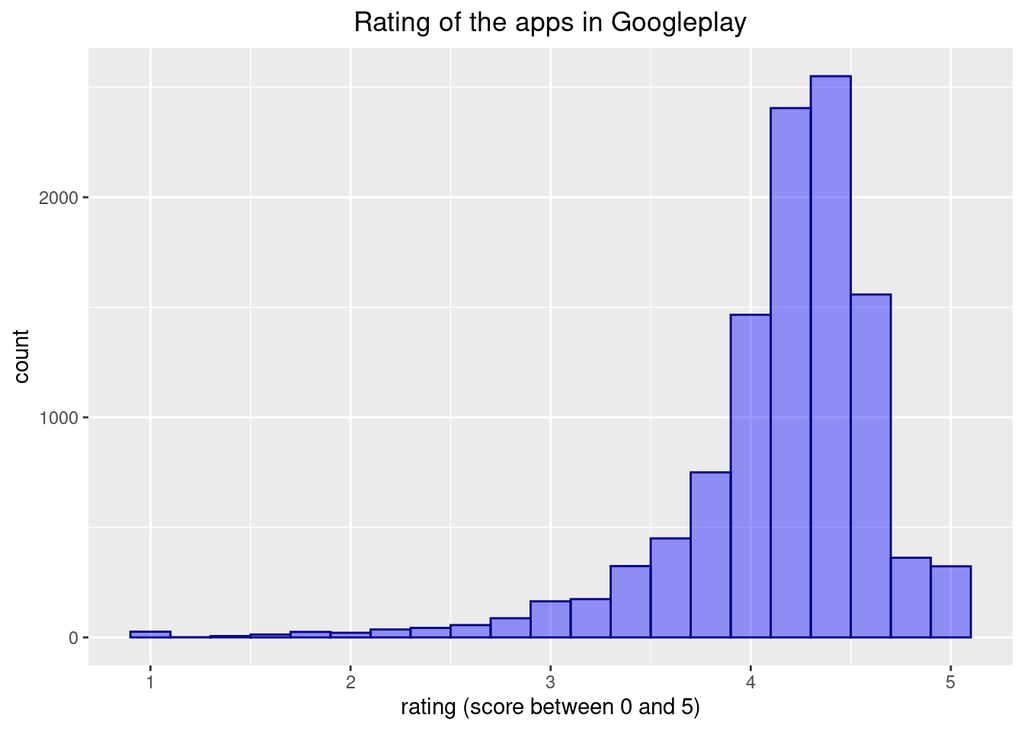

```r
ggplot(data_clean, aes(x=Rating))+
geom_histogram(binwidth= 0.2,color="darkblue", fill="blue", alpha=0.4)+
  xlab('rating (score between 0 and 5)')+
  ggtitle("Rating of the apps in Googleplay")+
  theme(plot.title = element_text(hjust = 0.5))
```

## 5.3 Matriz de correlaciones

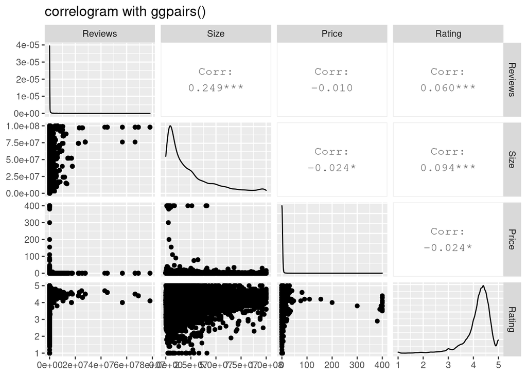

```r
ggpairs(data_clean[, c(4, 5, 8, 3)], title="correlogram with ggpairs()")
```

## 5.4 Matriz de correlaciones

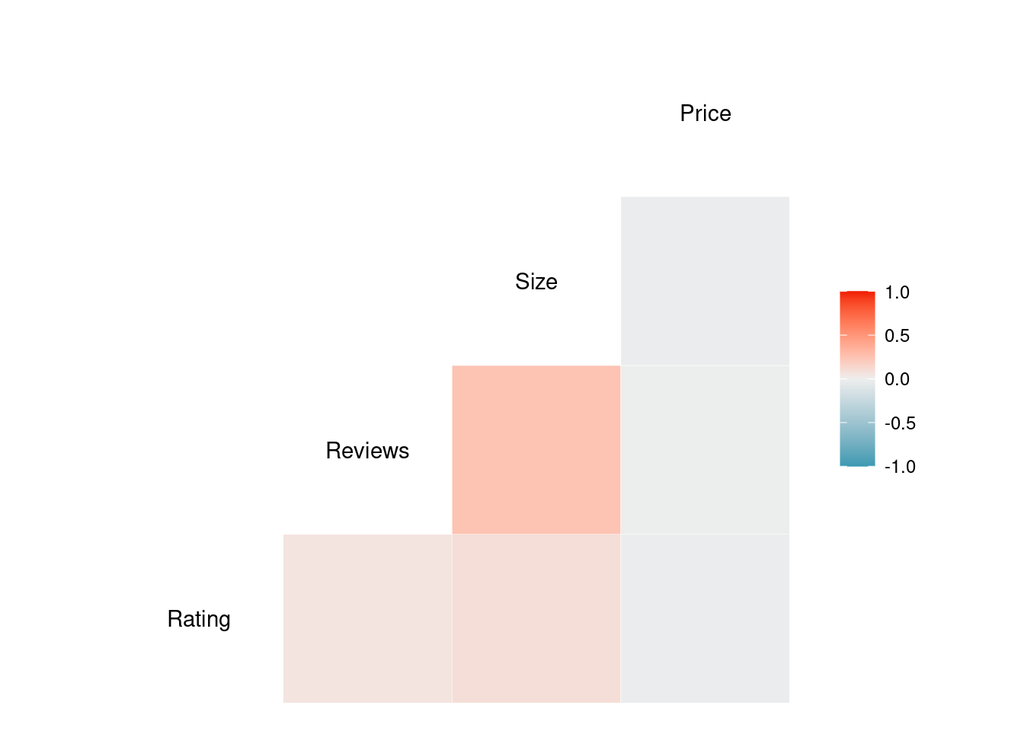

```r
ggcorr(data_clean, method = c("everything", "pearson"))
```

## 5.5 Diagramas de cajas de las categorias

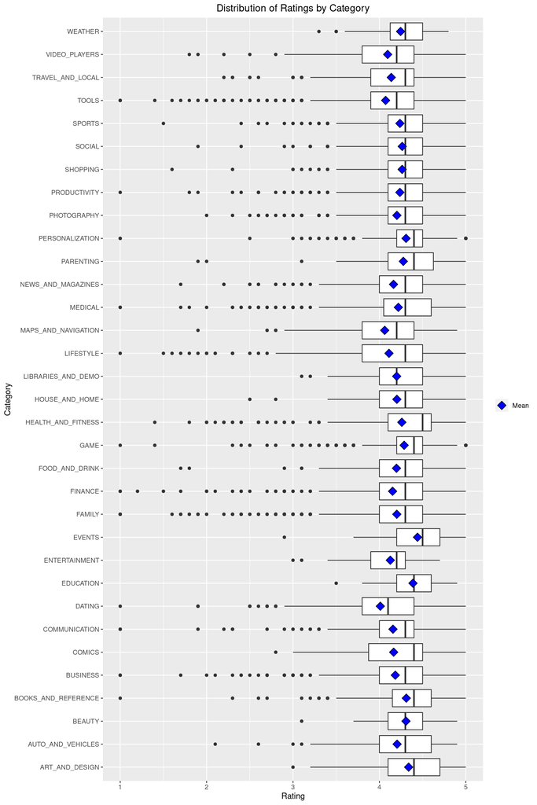

```r
ggplot(data_clean,aes(x=Rating,y=Category))+
  geom_boxplot() +
  geom_point(aes(fill='Mean'),stat='summary',
             fun.y=mean, shape = 23, size = 4) +
  scale_fill_manual('', values = c("Mean"='blue')) +
  xlab("Rating") +
  ylab("Category") +
  ggtitle("Distribution of Ratings by Category")+
  theme(plot.title = element_text(hjust = 0.5),legend.position="right")
```

## 5.6 Distribucion de las calificaciones por categoria

[figure not shown]

```r
ggplot(data_clean, aes(x=Rating))+
geom_histogram(binwidth= 0.2,color="darkblue", fill="blue", alpha=0.4)+
  facet_grid(rows=vars(Category))
```

## 5.7 Numero de apps por categoria

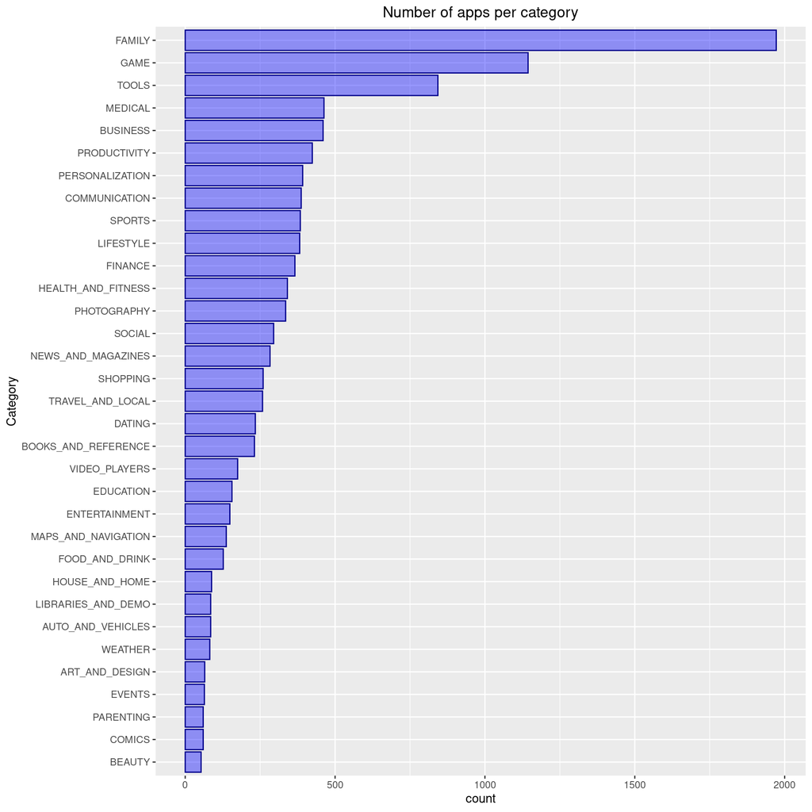

```r
data_clean <- within(data_clean,
Category <- factor(Category,
levels=names(sort(table(Category),
decreasing=FALSE))))

ggplot(data_clean, aes(y=Category))+
geom_bar(color="darkblue", fill="blue", alpha=0.4)+
ggtitle("Number of apps per category")+
theme(plot.title = element_text(hjust = 0.5))
```